# Action Seniors - CogFrailty Analyses (August 6, 2022)

RSF

2022-07-29

# 1) Data set-up and management

```r
if (!require("pacman")) install.packages("pacman")
```

```r
pacman::p_load(boot,MASS,readxl,mediation,plyr,sandwich,ggplot2,lme4,lmerTest,rpart,survival,survminer,lsmeans,fmsb, mice, mitools, tableone)


setwd("~/Desktop/Manuscripts/Ongoing Projects/ActionSeniors! Cognitive Frailty/")
data<-read_excel("ActionSeniors_CogsSPPB.xlsx")#Data#

data$CogFrail<-NA
data$CogFrail[data$SPPB_1<=9 & data$MoCA_1<26]<-"Yes"
data$CogFrail[data$SPPB_1>9 | data$MoCA_1>=26]<-"No"

data$exclude<-0
data$exclude[data$ID==330]<-1

data$Group.1<-NA
data$Group.1[data$Group==0]<-"Interview"
data$Group.1[data$Group==1]<-"Otago"

data$Group_r[data$Group==0]<-1
data$Group_r[data$Group==1]<-0

data$Gender<-NA
data$Gender[data$Sex==1]<-0
data$Gender[data$Sex==2]<-1

CogFrail<- subset(data, CogFrail=="Yes")

CogFrail$exclude<-0
CogFrail$exclude[CogFrail$ID==330]<-1

CogFrail$Group.1<-NA
CogFrail$Group.1[CogFrail$Group==0]<-"Interview"
CogFrail$Group.1[CogFrail$Group==1]<-"Otago"

CogFrail$Group_r[CogFrail$Group==0]<-1
CogFrail$Group_r[CogFrail$Group==1]<-0

CogFrail$Gender<-NA
CogFrail$Gender[CogFrail$Sex==1]<-0
CogFrail$Gender[CogFrail$Sex==2]<-1

No_CogFrail<- subset(data, CogFrail=="No")

No_CogFrail$exclude<-0
No_CogFrail$exclude[No_CogFrail$ID==330]<-1

No_CogFrail$Group.1<-NA
No_CogFrail$Group.1[No_CogFrail$Group==0]<-"Interview"
No_CogFrail$Group.1[No_CogFrail$Group==1]<-"Otago"

No_CogFrail$Group_r[No_CogFrail$Group==0]<-1
No_CogFrail$Group_r[No_CogFrail$Group==1]<-0

No_CogFrail$Gender<-NA
No_CogFrail$Gender[No_CogFrail$Sex==1]<-0
No_CogFrail$Gender[No_CogFrail$Sex==2]<-1


#Create long data set
library(plyr)
wide<-rename(data,c("Weight_1"="Weightbaseline", "Height_1"="Heightbaseline","BMI_1"="BMIbaseline",
                    "Falls 12M prior to baseline"="Fallsbeforebaseline", "Total_Exposure"="TotalExposure",
                    "Total_Falls"="TotalFalls","PPA_1"="PPAbaseline","GDS_1"="GDSbaseline","MoCA_1"="MoCAbaseline",
                    "Trails_BA_1"="TrailsBAbaseline","DSST_1"="DSSTbaseline","TUG_1"="TUGbaseline",
                    "SPPB_1"="SPPBbaseline","Gait_Speed_1"="GaitSpeedbaseline","Trails_BA_2"="TrailsBA_2",
                    "Trails_BA_3"="TrailsBA_3","Group_r"="Group.r","Gait_Speed_2"="GaitSpeed_2","Gait_Speed_3"="GaitSpeed_3"))
detach("package:plyr", unload = TRUE)

wide$StroopINTbaseline<-as.numeric(wide$Stroop_3_1) - as.numeric(wide$Stroop_2_1)
wide$StroopINT_2<-as.numeric(wide$Stroop_3_2) - as.numeric(wide$Stroop_2_2)
wide$StroopINT_3<-as.numeric(wide$Stroop_3_3) - as.numeric(wide$Stroop_2_3)

wide$DigitsFBbaseline<- wide$Digits_F_1 - wide$Digits_B_1
wide$DigitsFB_2<- wide$Digits_F_2 - wide$Digits_B_2
wide$DigitsFB_3<- wide$Digits_F_3 - wide$Digits_B_3

wide$time<-1

wide2<-wide[c(1,76,2:12,15,16,17,64:69,13,14,18,21,27,28,29,31,70,73,
              32:34,37,43:45,47,71,74,48:50,53,59:61,63,72,75)]
data2 <- reshape(as.data.frame(wide2),idvar="ID",varying=c(33:52),direction="long",sep="_")

CogFrail$Females<-NA
CogFrail$Females[CogFrail$Gender==1]<-"Female"
CogFrail$Females[CogFrail$Gender==0]<-"Male"

No_CogFrail$Females<-NA
No_CogFrail$Females[No_CogFrail$Gender==1]<-"Female"
No_CogFrail$Females[No_CogFrail$Gender==0]<-"Male"
```

# 2) Compliance data set-up

Note: All analyses used estimated average compliance for Cognitively Frail participants (44.0%) and non-CogFrail participants (51.1%). High compliance is ≥ mean compliance for each group.

```r
setwd("~/Desktop/Manuscripts/Ongoing Projects/ActionSeniors! Cognitive Frailty/")
compliancedata<-read_excel("jcd AS_compliance_Jul 2021.xlsx", sheet = "Compliance_for analysis") #Data#
```

```
## * `` -> ...69
```

```r
compliancedata2<-compliancedata[c(1,7,11,15,19,23,27,31,35,39,43,47,51,55,66)]
compliancedata2<-compliancedata2[-c(173:177),]
library(plyr)
compliancedata2<-rename(compliancedata2, c("id"="ID"))
detach("package:plyr", unload = TRUE)

OEP<-subset(wide, Group == 1)
compliancedata3<-merge(OEP,compliancedata2, by = c("ID"))
compliancedata3<-compliancedata3[c(1,3,65,77:90)]
library(plyr)
compliancedata3<-rename(compliancedata3, c("OEPCOMP1"="OEPCOMP_1","OEPCOMP2"="OEPCOMP_2","OEPCOMP3"="OEPCOMP_3","OEPCOMP4"="OEPCOMP_4","OEPCOMP5"="OEPCOMP_5","OEPCOMP6"="OEPCOMP_6",
                                           "OEPCOMP7"="OEPCOMP_7","OEPCOMP8"="OEPCOMP_8","OEPCOMP9"="OEPCOMP_9","OEPCOMP10"="OEPCOMP_10","OEPCOMP11"="OEPCOMP_11","OEPCOMP12"="OEPCOMP_12",
                                           "OEPCOMP13"="OEPCOMP_13"))
detach("package:plyr", unload = TRUE)

#long form
compliancelong <- reshape(as.data.frame(compliancedata3),idvar="ID",varying=c(4:16),direction="long",sep="_")

#Maximize compliance at 100% (i.e., compliance cannot be greater than 100%, regardless of how many times/month OEP was completed)
compliancelong$OEPCOMP[compliancelong$OEPCOMP>100]<-100

#Maximize compliance at 100% for each individual month
compliancedata2$OEPCOMP1[compliancedata2$OEPCOMP1>100]<-100
compliancedata2$OEPCOMP2[compliancedata2$OEPCOMP2>100]<-100
compliancedata2$OEPCOMP3[compliancedata2$OEPCOMP3>100]<-100
compliancedata2$OEPCOMP4[compliancedata2$OEPCOMP4>100]<-100
compliancedata2$OEPCOMP5[compliancedata2$OEPCOMP5>100]<-100
compliancedata2$OEPCOMP6[compliancedata2$OEPCOMP6>100]<-100
compliancedata2$OEPCOMP7[compliancedata2$OEPCOMP7>100]<-100
compliancedata2$OEPCOMP8[compliancedata2$OEPCOMP8>100]<-100
compliancedata2$OEPCOMP9[compliancedata2$OEPCOMP9>100]<-100
compliancedata2$OEPCOMP10[compliancedata2$OEPCOMP10>100]<-100
compliancedata2$OEPCOMP11[compliancedata2$OEPCOMP11>100]<-100
compliancedata2$OEPCOMP12[compliancedata2$OEPCOMP12>100]<-100
compliancedata2$OEPCOMP13[compliancedata2$OEPCOMP13>100]<-100

compliancedata2$AverageComply<-(compliancedata2[c(2)] + compliancedata2[c(3)] + compliancedata2[c(4)] + compliancedata2[c(5)] + compliancedata2[c(6)] + compliancedata2[c(7)] +
                                  compliancedata2[c(8)] + compliancedata2[c(9)] + compliancedata2[c(10)] + compliancedata2[c(11)] + compliancedata2[c(12)] + compliancedata2[c(13)] +
                                  compliancedata2[c(14)])/13

OEP2<-subset(wide2, Group == 1)


#Determine compliant vs. non compiant for CogFrail and Non-Frail
OEP2$Compliant<-NA
OEP2$Compliant[compliancedata2$AverageComply>=51.1 & OEP$CogFrail=="No" | compliancedata2$AverageComply>=44.0 & OEP$CogFrail=="Yes"] <- "Yes"
OEP2$Compliant[compliancedata2$AverageComply<51.1 & OEP$CogFrail=="No" | compliancedata2$AverageComply<44.0 & OEP$CogFrail=="Yes"] <- "No"

OEP3 <- reshape(as.data.frame(OEP2),idvar="ID",varying=c(33:52),direction="long",sep="_")
```

# 3) Figure 1 - CONSORT Flow Chart Stratified by Cognitive Frailty Status

```r
#Determine CogFrail Status of Dropouts
CONSORT<- subset(wide2, ID==128 | ID== 131 | ID==132 | ID==134 | ID==158 | ID==163 | ID==176 | ID==185 | ID==192 | ID==195 | ID==213 | ID==214 | ID==216 | ID==220 | ID==222 | ID==223 |
                   ID==270 | ID==278 | ID==281 | ID==284 | ID==306 | ID==310 | ID==318 | ID==321 | ID==330 | ID==334 | ID==339 | ID==357 | ID==362 | ID==369 | ID==373 | ID==375 | ID==378 |
                   ID==385 | ID==395 | ID==398 | ID==407 | ID==408 | ID==412 | ID==413 | ID==424 | ID==426 | ID==427 | ID==428 | ID==432 | ID==438 | ID==455 | ID==461) #All dropouts

CONSORT<-CONSORT[c(1,3,18)]
MONTHS<- c(13,2,1,0,0,0,13,0,0,13,2,4,0,11,3,5,1,5,2,5,0,0,3,0,0,5,0,4,5,5,5,7,6,1,1,9,1,7,9,2,4,1,7,7,5,11,7,10) #Months in study before drop-out
CONSORT<-cbind(CONSORT,MONTHS)

CONSORT$Group[CONSORT$Group==1]<-"INT"
CONSORT$Group[CONSORT$Group==0]<-"CON"

#Dropouts before 6 months (i.e., Month 7) or after 6 months in study
CONSORT$Timepoint<-NA
CONSORT$Timepoint[CONSORT$MONTHS<=7]<-"6 Months or Less"
CONSORT$Timepoint[CONSORT$MONTHS>7]<-"More than 6 Months"


#Sort by Group, Cognitive Frailty Status, and Time of Dropout
table(CONSORT$Timepoint,CONSORT$Group, CONSORT$CogFrail)
```

```
## , ,  = No
##
##
##                      CON INT
##   6 Months or Less     8   9
##   More than 6 Months   2   1
##
## , ,  = Yes
##
##
##                      CON INT
##   6 Months or Less    10  12
##   More than 6 Months   1   4
```

# 4) Table 1 - Participant Characteristics

```r
#Descriptive statistics for cognitively frail participants
cogfrail_vars<-dput(names(CogFrail[c(4,70,7,8,9,13,15,16,18,28,29,31)]))
```

```
## c("Age", "Females", "BMI_1", "Education", "Falls 12M prior to baseline",
## "PPA_1", "FCI", "IADL", "MoCA_1", "TUG_1", "SPPB_1", "Gait_Speed_1"
## )
```

```r
Table1_cogfrail_vars<-CreateTableOne(vars=cogfrail_vars, strata="Group", data=CogFrail)
print(Table1_cogfrail_vars,contDigits=2,missing=TRUE,quote=TRUE)
```

```
##                                                      "Stratified by Group"
##  ""                                                   "0"
##   "n"                                                 "   99"
##   "Age (mean (SD))"                                   "83.31 (5.88)"
##   "Females = Male (%)"                                "   62 (62.6) "
##   "BMI_1 (mean (SD))"                                 "27.03 (4.80)"
##   "Education (%)"                                     "   "
##   "   Grades 9-13, without certificate or diploma"    "   15 (15.2) "
##   "   High school certificate or diploma"             "   18 (18.2) "
##   "   Less than grade 9"                              "    2 ( 2.0) "
##   "   Some university without certificate or diploma" "    8 ( 8.1) "
##   "   Trades or professional certificate or diploma"  "   14 (14.1) "
##   "   University certificate or diploma"              "    4 ( 4.0) "
##   "   University degree"                              "   38 (38.4) "
##   "Falls 12M prior to baseline (mean (SD))"           " 2.84 (5.57)"
##   "PPA_1 (mean (SD))"                                 " 2.20 (0.98)"
##   "FCI (mean (SD))"                                   " 4.04 (1.93)"
##   "IADL (mean (SD))"                                  " 7.17 (1.27)"
##   "MoCA_1 (mean (SD))"                                "21.90 (2.38)"
##   "TUG_1 (mean (SD))"                                 "18.68 (6.76)"
##   "SPPB_1 (mean (SD))"                                " 6.70 (1.88)"
##   "Gait_Speed_1 (mean (SD))"                          " 0.80 (0.23)"
##                                                      "Stratified by Group"
##  ""                                                   "1"             "p"
##   "n"                                                 "   93"         ""
##   "Age (mean (SD))"                                   "81.62 (6.55)"  " 0.061"
##   "Females = Male (%)"                                "   61 (65.6) " " 0.781"
##   "BMI_1 (mean (SD))"                                 "28.16 (8.79)"  " 0.269"
##   "Education (%)"                                     "   "           " 0.260"
##   "   Grades 9-13, without certificate or diploma"    "    5 ( 5.4) " ""
##   "   High school certificate or diploma"             "   20 (21.5) " ""
##   "   Less than grade 9"                              "    6 ( 6.5) " ""
##   "   Some university without certificate or diploma" "    8 ( 8.6) " ""
##   "   Trades or professional certificate or diploma"  "   15 (16.1) " ""
##   "   University certificate or diploma"              "    6 ( 6.5) " ""
##   "   University degree"                              "   33 (35.5) " ""
##   "Falls 12M prior to baseline (mean (SD))"           " 2.47 (2.58)"  " 0.565"
##   "PPA_1 (mean (SD))"                                 " 2.15 (0.99)"  " 0.737"
##   "FCI (mean (SD))"                                   " 4.02 (2.03)"  " 0.948"
##   "IADL (mean (SD))"                                  " 7.14 (1.34)"  " 0.859"
```

[output cut: 11 more lines]

```
##   "   Grades 9-13, without certificate or diploma"    ""     "   "
##   "   High school certificate or diploma"             ""     "   "
##   "   Less than grade 9"                              ""     "   "
##   "   Some university without certificate or diploma" ""     "   "
##   "   Trades or professional certificate or diploma"  ""     "   "
##   "   University certificate or diploma"              ""     "   "
##   "   University degree"                              ""     "   "
##   "Falls 12M prior to baseline (mean (SD))"           ""     "0.0"
##   "PPA_1 (mean (SD))"                                 ""     "0.0"
##   "FCI (mean (SD))"                                   ""     "0.5"
##   "IADL (mean (SD))"                                  ""     "0.5"
##   "MoCA_1 (mean (SD))"                                ""     "0.0"
##   "TUG_1 (mean (SD))"                                 ""     "0.5"
##   "SPPB_1 (mean (SD))"                                ""     "0.0"
##   "Gait_Speed_1 (mean (SD))"                          ""     "0.0"
```

```r
#Descriptive statistics for non-cognitively frail participants
nocogfrail_vars<-dput(names(No_CogFrail[c(4,70,7,8,9,13,15,16,18,28,29,31)]))
```

```
## c("Age", "Females", "BMI_1", "Education", "Falls 12M prior to baseline",
## "PPA_1", "FCI", "IADL", "MoCA_1", "TUG_1", "SPPB_1", "Gait_Speed_1"
## )
```

```r
Table1_nocogfrail_vars<-CreateTableOne(vars=nocogfrail_vars, strata="Group", data=No_CogFrail)
print(Table1_nocogfrail_vars,contDigits=2,missing=TRUE,quote=TRUE)
```

```
##                                                      "Stratified by Group"
##  ""                                                   "0"
##   "n"                                                 "   73"
##   "Age (mean (SD))"                                   "80.01 (5.84)"
##   "Females = Male (%)"                                "   57 (78.1) "
##   "BMI_1 (mean (SD))"                                 "27.09 (5.06)"
##   "Education (%)"                                     "   "
##   "   Grades 9-13, without certificate or diploma"    "    5 ( 6.8) "
##   "   High school certificate or diploma"             "   14 (19.2) "
##   "   Less than grade 9"                              "    0 ( 0.0) "
##   "   Some university without certificate or diploma" "    6 ( 8.2) "
##   "   Trades or professional certificate or diploma"  "    7 ( 9.6) "
##   "   University certificate or diploma"              "    5 ( 6.8) "
##   "   University degree"                              "   36 (49.3) "
##   "Falls 12M prior to baseline (mean (SD))"           " 1.67 (1.95)"
##   "PPA_1 (mean (SD))"                                 " 1.57 (1.20)"
##   "FCI (mean (SD))"                                   " 3.88 (2.06)"
##   "IADL (mean (SD))"                                  " 7.62 (0.83)"
##   "MoCA_1 (mean (SD))"                                "25.38 (3.28)"
##   "TUG_1 (mean (SD))"                                 "14.45 (4.94)"
##   "SPPB_1 (mean (SD))"                                " 9.36 (1.97)"
##   "Gait_Speed_1 (mean (SD))"                          " 0.96 (0.20)"
##                                                      "Stratified by Group"
##  ""                                                   "1"             "p"
##   "n"                                                 "   79"         ""
##   "Age (mean (SD))"                                   "80.71 (5.53)"  " 0.452"
##   "Females = Male (%)"                                "   49 (62.0) " " 0.048"
##   "BMI_1 (mean (SD))"                                 "25.98 (7.38)"  " 0.286"
##   "Education (%)"                                     "   "           " 0.454"
##   "   Grades 9-13, without certificate or diploma"    "    9 (11.5) " ""
##   "   High school certificate or diploma"             "    8 (10.3) " ""
##   "   Less than grade 9"                              "    1 ( 1.3) " ""
##   "   Some university without certificate or diploma" "    8 (10.3) " ""
##   "   Trades or professional certificate or diploma"  "   12 (15.4) " ""
##   "   University certificate or diploma"              "    3 ( 3.8) " ""
##   "   University degree"                              "   37 (47.4) " ""
##   "Falls 12M prior to baseline (mean (SD))"           " 1.80 (1.89)"  " 0.686"
##   "PPA_1 (mean (SD))"                                 " 1.64 (1.07)"  " 0.685"
##   "FCI (mean (SD))"                                   " 4.11 (2.38)"  " 0.512"
##   "IADL (mean (SD))"                                  " 7.38 (1.03)"  " 0.122"
```

[output cut: 11 more lines]

```
##   "   Grades 9-13, without certificate or diploma"    ""     "   "
##   "   High school certificate or diploma"             ""     "   "
##   "   Less than grade 9"                              ""     "   "
##   "   Some university without certificate or diploma" ""     "   "
##   "   Trades or professional certificate or diploma"  ""     "   "
##   "   University certificate or diploma"              ""     "   "
##   "   University degree"                              ""     "   "
##   "Falls 12M prior to baseline (mean (SD))"           ""     "0.0"
##   "PPA_1 (mean (SD))"                                 ""     "0.0"
##   "FCI (mean (SD))"                                   ""     "0.7"
##   "IADL (mean (SD))"                                  ""     "0.0"
##   "MoCA_1 (mean (SD))"                                ""     "0.0"
##   "TUG_1 (mean (SD))"                                 ""     "0.0"
##   "SPPB_1 (mean (SD))"                                ""     "0.0"
##   "Gait_Speed_1 (mean (SD))"                          ""     "0.0"
```

# 5) Table 2 - Differences in baseline characteristics by Cognitive Frailty status

```r
Supp<-wide2
Supp$Females<-NA
Supp$Females[Supp$Sex==1]<-"Female"
Supp$Females[Supp$Sex==2]<-"Male"

supp_vars<-dput(names(Supp[c(5,53,8,9,10,14,15,23,25,28,29,30)]))
```

```
## c("Age", "Females", "BMIbaseline", "Education", "Fallsbeforebaseline",
## "FCI", "IADL", "PPAbaseline", "MoCAbaseline", "TUGbaseline",
## "SPPBbaseline", "GaitSpeedbaseline")
```

```r
SuppTable1<-CreateTableOne(vars=supp_vars, strata="CogFrail", data=Supp)
print(SuppTable1, contDigits=2, missing=TRUE, quote=TRUE)
```

```
##                                                      "Stratified by CogFrail"
##  ""                                                   "No"
##   "n"                                                 "  152"
##   "Age (mean (SD))"                                   "80.38 (5.67)"
##   "Females = Male (%)"                                "   46 (30.3) "
##   "BMIbaseline (mean (SD))"                           "26.51 (6.38)"
##   "Education (%)"                                     "   "
##   "   Grades 9-13, without certificate or diploma"    "   14 ( 9.3) "
##   "   High school certificate or diploma"             "   22 (14.6) "
##   "   Less than grade 9"                              "    1 ( 0.7) "
##   "   Some university without certificate or diploma" "   14 ( 9.3) "
##   "   Trades or professional certificate or diploma"  "   19 (12.6) "
##   "   University certificate or diploma"              "    8 ( 5.3) "
##   "   University degree"                              "   73 (48.3) "
##   "Fallsbeforebaseline (mean (SD))"                   " 1.74 (1.91)"
##   "FCI (mean (SD))"                                   " 4.00 (2.23)"
##   "IADL (mean (SD))"                                  " 7.49 (0.94)"
##   "PPAbaseline (mean (SD))"                           " 1.60 (1.13)"
##   "MoCAbaseline (mean (SD))"                          "25.03 (3.22)"
##   "TUGbaseline (mean (SD))"                           "14.19 (5.07)"
##   "SPPBbaseline (mean (SD))"                          " 9.24 (2.04)"
##   "GaitSpeedbaseline (mean (SD))"                     " 0.98 (0.21)"
##                                                      "Stratified by CogFrail"
##  ""                                                   "Yes"           "p"
##   "n"                                                 "  192"         ""
##   "Age (mean (SD))"                                   "82.49 (6.26)"  " 0.001"
##   "Females = Male (%)"                                "   69 (35.9) " " 0.321"
##   "BMIbaseline (mean (SD))"                           "27.58 (7.02)"  " 0.148"
##   "Education (%)"                                     "   "           " 0.207"
##   "   Grades 9-13, without certificate or diploma"    "   20 (10.4) " ""
##   "   High school certificate or diploma"             "   38 (19.8) " ""
##   "   Less than grade 9"                              "    8 ( 4.2) " ""
##   "   Some university without certificate or diploma" "   16 ( 8.3) " ""
##   "   Trades or professional certificate or diploma"  "   29 (15.1) " ""
##   "   University certificate or diploma"              "   10 ( 5.2) " ""
##   "   University degree"                              "   71 (37.0) " ""
##   "Fallsbeforebaseline (mean (SD))"                   " 2.66 (4.38)"  " 0.016"
##   "FCI (mean (SD))"                                   " 4.03 (1.97)"  " 0.890"
##   "IADL (mean (SD))"                                  " 7.16 (1.30)"  " 0.008"
##   "PPAbaseline (mean (SD))"                           " 2.18 (0.98)"  "<0.001"
```

[output cut: 11 more lines]

```
##   "   Grades 9-13, without certificate or diploma"    ""     "   "
##   "   High school certificate or diploma"             ""     "   "
##   "   Less than grade 9"                              ""     "   "
##   "   Some university without certificate or diploma" ""     "   "
##   "   Trades or professional certificate or diploma"  ""     "   "
##   "   University certificate or diploma"              ""     "   "
##   "   University degree"                              ""     "   "
##   "Fallsbeforebaseline (mean (SD))"                   ""     "0.3"
##   "FCI (mean (SD))"                                   ""     "0.9"
##   "IADL (mean (SD))"                                  ""     "0.6"
##   "PPAbaseline (mean (SD))"                           ""     "0.3"
##   "MoCAbaseline (mean (SD))"                          ""     "0.3"
##   "TUGbaseline (mean (SD))"                           ""     "0.6"
##   "SPPBbaseline (mean (SD))"                          ""     "0.3"
##   "GaitSpeedbaseline (mean (SD))"                     ""     "0.3"
```

# 6) Supplementary Figure S1 - Differences in individual monthly compliance

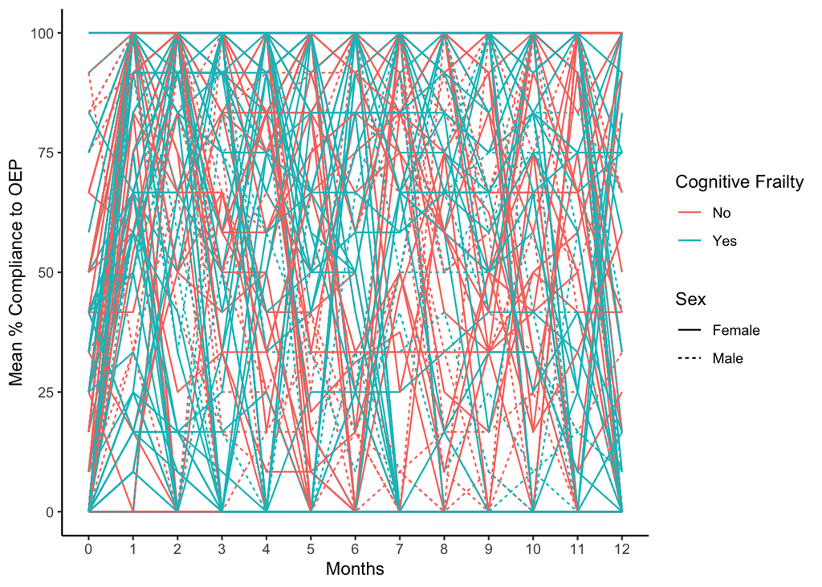

```r
compliancelong$Timepoint<-NA
compliancelong$Timepoint[compliancelong$time==1]<-0
compliancelong$Timepoint[compliancelong$time==2]<-1
compliancelong$Timepoint[compliancelong$time==3]<-2
compliancelong$Timepoint[compliancelong$time==4]<-3
compliancelong$Timepoint[compliancelong$time==5]<-4
compliancelong$Timepoint[compliancelong$time==6]<-5
compliancelong$Timepoint[compliancelong$time==7]<-6
compliancelong$Timepoint[compliancelong$time==8]<-7
compliancelong$Timepoint[compliancelong$time==9]<-8
compliancelong$Timepoint[compliancelong$time==10]<-9
compliancelong$Timepoint[compliancelong$time==11]<-10
compliancelong$Timepoint[compliancelong$time==12]<-11
compliancelong$Timepoint[compliancelong$time==13]<-12
compliancelong$Timepoint<-as.factor(compliancelong$Timepoint)

compliancelong$Sex[compliancelong$Sex==1]<-"Female"
compliancelong$Sex[compliancelong$Sex==2]<-"Male"

library(forcats)

Compliance.Graph<- compliancelong %>%
  ggplot() + geom_line(aes(x=Timepoint, y=OEPCOMP, group=ID, color=CogFrail, linetype=Sex)) +
  labs(x="Months", y="Mean % Compliance to OEP") + ylim(0,100) + labs(color="Cognitive Frailty") +
  theme_bw() + theme(panel.border = element_blank(), panel.grid.major = element_blank(),
                     panel.grid.minor = element_blank(), axis.line = element_line(colour = "black"))
Compliance.Graph
```

# 7) Table 3 - Primary and secondary outcomes at 12 months by cognitive frailty status and treatment group

Falls Incident Rate Ratio (Cognitively Frail Participants)

```r
mdl.nb<-glm.nb(Total_Falls~Group.1+scale(Gender,scale=FALSE)+offset(log(Total_Exposure/365)),subset(CogFrail,exclude==0))
print(summary(mdl.nb))
```

```
##
## Call:
## glm.nb(formula = Total_Falls ~ Group.1 + scale(Gender, scale = FALSE) +
##     offset(log(Total_Exposure/365)), data = subset(CogFrail,
##     exclude == 0), init.theta = 0.8504452563, link = log)
##
## Deviance Residuals:
##     Min       1Q   Median       3Q      Max
## -1.7635  -1.2540  -0.4557   0.2632   2.7073
##
## Coefficients:
##                              Estimate Std. Error z value Pr(>|z|)
## (Intercept)                    0.9108     0.1289   7.067 1.59e-12 ***
## Group.1Otago                  -0.4291     0.1934  -2.219  0.02650 *
## scale(Gender, scale = FALSE)   0.6250     0.1960   3.188  0.00143 **
## ---
## Signif. codes:  0 '***' 0.001 '**' 0.01 '*' 0.05 '.' 0.1 ' ' 1
##
## (Dispersion parameter for Negative Binomial(0.8504) family taken to be 1)
##
##     Null deviance: 210.58  on 191  degrees of freedom
## Residual deviance: 194.36  on 189  degrees of freedom
## AIC: 707.84
##
## Number of Fisher Scoring iterations: 1
##
##
##               Theta:  0.850
##           Std. Err.:  0.143
##
##  2 x log-likelihood:  -699.842
```

```r
SE<-sqrt(diag(vcovHC(mdl.nb,"HC1")))
p=2*pnorm(-abs(coef(mdl.nb)/SE))
print(cbind(coef(mdl.nb),SE,p))
```

```
##                                                SE            p
## (Intercept)                   0.9108292 0.1626557 2.146786e-08
## Group.1Otago                 -0.4291280 0.2110955 4.206649e-02
## scale(Gender, scale = FALSE)  0.6250177 0.2118145 3.169745e-03
```

```r
est<-cbind(Estimate=coef(mdl.nb),LL=coef(mdl.nb)-1.96*SE,UL=coef(mdl.nb)+1.96*SE)
exp_group<-exp(est)
print("Use these estimates and LL and UL for the 95% CI");exp_group
```

```
## [1] "Use these estimates and LL and UL for the 95% CI"
```

```
##                               Estimate       LL        UL
## (Intercept)                  2.4863834 1.807643 3.4199792
## Group.1Otago                 0.6510766 0.430471 0.9847369
## scale(Gender, scale = FALSE) 1.8682790 1.233507 2.8297099
```

```r
print("Significant effect of intervention on falls risk for participants with CogFrailty")
```

```
## [1] "Significant effect of intervention on falls risk for participants with CogFrailty"
```

Falls Incident Rate Ratio (Non-Cognitively Frail Participants)

```r
mdl.nb<-glm.nb(Total_Falls~Group.1+scale(Gender,scale=FALSE)+offset(log(Total_Exposure/365)),subset(No_CogFrail,exclude==0))
print(summary(mdl.nb))
```

```
##
## Call:
## glm.nb(formula = Total_Falls ~ Group.1 + scale(Gender, scale = FALSE) +
##     offset(log(Total_Exposure/365)), data = subset(No_CogFrail,
##     exclude == 0), init.theta = 0.9043176586, link = log)
##
## Deviance Residuals:
##     Min       1Q   Median       3Q      Max
## -1.5018  -1.2040  -0.3149   0.1835   3.9449
##
## Coefficients:
##                              Estimate Std. Error z value Pr(>|z|)
## (Intercept)                    0.5727     0.1566   3.657 0.000255 ***
## Group.1Otago                  -0.3651     0.2273  -1.606 0.108266
## scale(Gender, scale = FALSE)   0.3370     0.2405   1.401 0.161152
## ---
## Signif. codes:  0 '***' 0.001 '**' 0.01 '*' 0.05 '.' 0.1 ' ' 1
##
## (Dispersion parameter for Negative Binomial(0.9043) family taken to be 1)
##
##     Null deviance: 149.51  on 151  degrees of freedom
## Residual deviance: 145.88  on 149  degrees of freedom
## AIC: 487.49
##
## Number of Fisher Scoring iterations: 1
##
##
##               Theta:  0.904
##           Std. Err.:  0.189
##
##  2 x log-likelihood:  -479.488
```

```r
SE<-sqrt(diag(vcovHC(mdl.nb,"HC1")))
p=2*pnorm(-abs(coef(mdl.nb)/SE))
print(cbind(coef(mdl.nb),SE,p))
```

```
##                                                SE          p
## (Intercept)                   0.5727499 0.2583403 0.02662057
## Group.1Otago                 -0.3651257 0.2771717 0.18772909
## scale(Gender, scale = FALSE)  0.3369836 0.2401623 0.16057238
```

```r
est<-cbind(Estimate=coef(mdl.nb),LL=coef(mdl.nb)-1.96*SE,UL=coef(mdl.nb)+1.96*SE)
exp_group<-exp(est)
print("Use these estimates and LL and UL for the 95% CI");exp_group
```

```
## [1] "Use these estimates and LL and UL for the 95% CI"
```

```
##                               Estimate        LL       UL
## (Intercept)                  1.7731364 1.0686573 2.942021
## Group.1Otago                 0.6941094 0.4031759 1.194982
## scale(Gender, scale = FALSE) 1.4007161 0.8748222 2.242748
```

```r
print("No significant effect of intervention on falls risk for participants without CogFrailty")
```

```
## [1] "No significant effect of intervention on falls risk for participants without CogFrailty"
```

Differences in total exposure based on cognitive frailty and group

```r
exposurelm<-lm(TotalExposure~Group*CogFrail, wide2)
lsmeans(exposurelm, ~Group|CogFrail)
```

```
## CogFrail = No:
##  Group lsmean   SE  df lower.CL upper.CL
##      0    340 9.51 340      322      359
##      1    339 9.14 340      321      357
##
## CogFrail = Yes:
##  Group lsmean   SE  df lower.CL upper.CL
##      0    345 8.17 340      329      361
##      1    329 8.43 340      312      345
##
## Confidence level used: 0.95
```

```r
contrast(lsmeans(exposurelm, ~Group|CogFrail), "trt.vs.ctrl", adj="none")
```

```
## CogFrail = No:
##  contrast estimate   SE  df t.ratio p.value
##  1 - 0      -0.878 13.2 340  -0.067  0.9470
##
## CogFrail = Yes:
##  contrast estimate   SE  df t.ratio p.value
##  1 - 0     -16.078 11.7 340  -1.370  0.1717
```

Differences in the cumulative number of falls by group and cognitive frailty

```r
setwd("~/Desktop/Manuscripts/Ongoing Projects/ActionSeniors! Cognitive Frailty/")
Monthly_falls <- read_excel("AS_Monthly falls_Mar 20 2019.xlsx")
Monthly_falls<-subset(Monthly_falls, ID %in% wide2$ID)

data1c<-cbind(Monthly_falls,wide2$CogFrail,wide2$Group)
data1c<-subset(data1c,ID!=330)

data1c<-plyr::rename(data1c,c("Month_1_Cumulative"="MonthCumulative_1","Month_2_Cumulative"="MonthCumulative_2","Month_3_Cumulative"="MonthCumulative_3",
                              "Month_4_Cumulative"="MonthCumulative_4","Month_5_Cumulative"="MonthCumulative_5","Month_6_Cumulative"="MonthCumulative_6",
                              "Month_7_Cumulative"="MonthCumulative_7","Month_8_Cumulative"="MonthCumulative_8","Month_9_Cumulative"="MonthCumulative_9",
                              "Month_10_Cumulative"="MonthCumulative_10","Month_11_Cumulative"="MonthCumulative_11","Month_12_Cumulative"="MonthCumulative_12",
                              "Month_13_Cumulative"="MonthCumulative_13","wide2$CogFrail"="CogFrail","wide2$Group"="Group"))
data1c_CogFrail_EX<-subset(data1c,Group==1 & CogFrail=="Yes")
data1c_CogFrail_UC<-subset(data1c,Group==0 & CogFrail=="Yes")
data1c_NoCogFrail_EX<-subset(data1c,Group==1 & CogFrail=="No")
data1c_NoCogFrail_UC<-subset(data1c,Group==0 & CogFrail=="No")

print("CogFrail Exercise");apply(data1c_CogFrail_EX[c(2:14)], 2, function(x) length(which(!is.na(x)))) #count people with falls data
```

```
## [1] "CogFrail Exercise"
```

```
##  Month_1  Month_2  Month_3  Month_4  Month_5  Month_6  Month_7  Month_8
##       89       87       86       84       82       80       80       80
##  Month_9 Month_10 Month_11 Month_12 Month_13
##       78       77       76       75       75
```

```r
print("CogFrail Usual Care");apply(data1c_CogFrail_UC[c(2:14)], 2, function(x) length(which(!is.na(x)))) #count people with falls data
```

```
## [1] "CogFrail Usual Care"
```

```
##  Month_1  Month_2  Month_3  Month_4  Month_5  Month_6  Month_7  Month_8
##       98       97       95       94       93       89       89       87
##  Month_9 Month_10 Month_11 Month_12 Month_13
##       87       86       86       85       82
```

```r
print("No CogFrail Exercise");apply(data1c_NoCogFrail_EX[c(2:14)], 2, function(x) length(which(!is.na(x)))) #count people with falls data
```

```
## [1] "No CogFrail Exercise"
```

```
##  Month_1  Month_2  Month_3  Month_4  Month_5  Month_6  Month_7  Month_8
##       76       76       73       73       73       72       71       70
##  Month_9 Month_10 Month_11 Month_12 Month_13
##       70       70       68       68       67
```

```r
print("No CogFrail Usual Care");apply(data1c_NoCogFrail_UC[c(2:14)], 2, function(x) length(which(!is.na(x)))) #count people with falls data
```

```
## [1] "No CogFrail Usual Care"
```

```
##  Month_1  Month_2  Month_3  Month_4  Month_5  Month_6  Month_7  Month_8
##       70       70       69       68       67       66       65       65
##  Month_9 Month_10 Month_11 Month_12 Month_13
##       65       64       63       63       62
```

```r
data1c.stacked<-reshape(data1c,idvar="ID",varying=c(2:27),direction="long",sep="_")
data1c.stacked$time<-data1c.stacked$time-1

Fallsmeans<-data.frame(aggregate(MonthCumulative~Group*CogFrail+time,data1c.stacked,sum))
Fallsmeans
```

```
##    Group CogFrail time MonthCumulative
## 1      0       No    0               3
## 2      1       No    0               4
## 3      0      Yes    0              14
## 4      1      Yes    0              10
## 5      0       No    1              10
## 6      1       No    1              13
## 7      0      Yes    1              41
## 8      1      Yes    1              24
## 9      0       No    2              18
## 10     1       No    2              22
## 11     0      Yes    2              60
## 12     1      Yes    2              41
## 13     0       No    3              22
## 14     1       No    3              29
```

[output cut: 38 more lines]

Estimated differences in falls per person-year

```r
wide2$falls_ppy<-wide2$TotalFalls/(wide2$TotalExposure/365)

fallsppy_lm<-lm(falls_ppy~Group*CogFrail, wide2)
summary(fallsppy_lm)
```

```
##
## Call:
## lm(formula = falls_ppy ~ Group * CogFrail, data = wide2)
##
## Residuals:
##     Min      1Q  Median      3Q     Max
## -2.6359 -1.6359 -0.6359  0.4057 22.3583
##
## Coefficients:
##                   Estimate Std. Error t value Pr(>|t|)
## (Intercept)         1.6417     0.3581   4.585 6.39e-06 ***
## Group              -0.3854     0.4967  -0.776   0.4383
## CogFrailYes         0.9942     0.4720   2.107   0.0359 *
## Group:CogFrailYes  -0.6562     0.6647  -0.987   0.3243
## ---
## Signif. codes:  0 '***' 0.001 '**' 0.01 '*' 0.05 '.' 0.1 ' ' 1
##
## Residual standard error: 3.059 on 340 degrees of freedom
##   (1 observation deleted due to missingness)
## Multiple R-squared:  0.02989,    Adjusted R-squared:  0.02133
## F-statistic: 3.492 on 3 and 340 DF,  p-value: 0.01593
```

```r
lsmeans(fallsppy_lm, ~Group|CogFrail)
```

```
## CogFrail = No:
##  Group lsmean    SE  df lower.CL upper.CL
##      0   1.64 0.358 340    0.937     2.35
##      1   1.26 0.344 340    0.579     1.93
##
## CogFrail = Yes:
##  Group lsmean    SE  df lower.CL upper.CL
##      0   2.64 0.307 340    2.031     3.24
##      1   1.59 0.317 340    0.970     2.22
##
## Confidence level used: 0.95
```

```r
contrast(lsmeans(fallsppy_lm, ~~Group|CogFrail), "trt.vs.ctrl", adj="none")
```

```
## CogFrail = No:
##  contrast estimate    SE  df t.ratio p.value
##  1 - 0      -0.385 0.497 340  -0.776  0.4383
##
## CogFrail = Yes:
##  contrast estimate    SE  df t.ratio p.value
##  1 - 0      -1.042 0.442 340  -2.358  0.0190
```

Differences in exposure time

```r
expopsure_lm<-lm(TotalExposure~Group*CogFrail, wide2)
summary(expopsure_lm)
```

```
##
## Call:
## lm(formula = TotalExposure ~ Group * CogFrail, data = wide2)
##
## Residuals:
##     Min      1Q  Median      3Q     Max
## -339.23   20.20   24.77   25.65  130.77
##
## Coefficients:
##                   Estimate Std. Error t value Pr(>|t|)
## (Intercept)       340.2329     9.5130  35.765   <2e-16 ***
## Group              -0.8784    13.1955  -0.067    0.947
## CogFrailYes         4.5651    12.5390   0.364    0.716
## Group:CogFrailYes -15.1991    17.6603  -0.861    0.390
## ---
## Signif. codes:  0 '***' 0.001 '**' 0.01 '*' 0.05 '.' 0.1 ' ' 1
##
## Residual standard error: 81.28 on 340 degrees of freedom
##   (1 observation deleted due to missingness)
## Multiple R-squared:  0.005787,   Adjusted R-squared:  -0.002986
## F-statistic: 0.6597 on 3 and 340 DF,  p-value: 0.5774
```

```r
lsmeans(expopsure_lm, ~Group|CogFrail)
```

```
## CogFrail = No:
##  Group lsmean   SE  df lower.CL upper.CL
##      0    340 9.51 340      322      359
##      1    339 9.14 340      321      357
##
## CogFrail = Yes:
##  Group lsmean   SE  df lower.CL upper.CL
##      0    345 8.17 340      329      361
##      1    329 8.43 340      312      345
##
## Confidence level used: 0.95
```

```r
contrast(lsmeans(expopsure_lm, ~~Group|CogFrail), "trt.vs.ctrl", adj="none")
```

```
## CogFrail = No:
##  contrast estimate   SE  df t.ratio p.value
##  1 - 0      -0.878 13.2 340  -0.067  0.9470
##
## CogFrail = Yes:
##  contrast estimate   SE  df t.ratio p.value
##  1 - 0     -16.078 11.7 340  -1.370  0.1717
```

PPA

```r
PPA_lm<-lmer(PPA~Group.1*CogFrail*factor(time) + scale(Gender,scale=FALSE) + PPAbaseline + 1 + (1|ID), subset(data2, exclude == 0))
anova(PPA_lm)
```

```
## Type III Analysis of Variance Table with Satterthwaite's method
##                               Sum Sq Mean Sq NumDF  DenDF  F value    Pr(>F)
## Group.1                        0.071   0.071     1 282.25   0.1340  0.714603
## CogFrail                       2.222   2.222     1 284.95   4.2217  0.040821
## factor(time)                   0.265   0.265     1 267.31   0.5041  0.478309
## scale(Gender, scale = FALSE)   0.152   0.152     1 284.27   0.2883  0.591737
## PPAbaseline                   54.985  54.985     1 284.17 104.4735 < 2.2e-16
## Group.1:CogFrail               0.945   0.945     1 282.68   1.7962  0.181250
## Group.1:factor(time)           0.760   0.760     1 267.30   1.4445  0.230484
## CogFrail:factor(time)          2.233   2.233     1 267.07   4.2429  0.040383
## Group.1:CogFrail:factor(time)  3.874   3.874     1 267.25   7.3604  0.007101
##
## Group.1
## CogFrail                      *
## factor(time)
## scale(Gender, scale = FALSE)
## PPAbaseline                   ***
## Group.1:CogFrail
## Group.1:factor(time)
## CogFrail:factor(time)         *
## Group.1:CogFrail:factor(time) **
## ---
## Signif. codes:  0 '***' 0.001 '**' 0.01 '*' 0.05 '.' 0.1 ' ' 1
```

```r
lsmeans(PPA_lm, ~Group.1|CogFrail|factor(time))
```

```
## CogFrail = No, time = 2:
##  Group.1   lsmean    SE  df lower.CL upper.CL
##  Interview   1.80 0.125 451     1.55     2.04
##  Otago       1.71 0.119 457     1.48     1.95
##
## CogFrail = Yes, time = 2:
##  Group.1   lsmean    SE  df lower.CL upper.CL
##  Interview   2.09 0.107 463     1.88     2.30
##  Otago       2.10 0.114 462     1.87     2.32
##
## CogFrail = No, time = 3:
##  Group.1   lsmean    SE  df lower.CL upper.CL
##  Interview   1.72 0.131 479     1.47     1.98
##  Otago       2.14 0.121 468     1.90     2.38
##
## CogFrail = Yes, time = 3:
##  Group.1   lsmean    SE  df lower.CL upper.CL
##  Interview   2.10 0.110 473     1.89     2.32
##  Otago       1.91 0.117 474     1.68     2.14
##
## Results are averaged over the levels of: Gender
## Degrees-of-freedom method: kenward-roger
## Confidence level used: 0.95
```

```r
contrast(lsmeans(PPA_lm, ~Group.1|CogFrail|factor(time)), "trt.vs.ctrl", adj="none")
```

```
## CogFrail = No, time = 2:
##  contrast          estimate    SE  df t.ratio p.value
##  Otago - Interview -0.08374 0.169 461  -0.496  0.6203
##
## CogFrail = Yes, time = 2:
##  contrast          estimate    SE  df t.ratio p.value
##  Otago - Interview  0.00185 0.154 467   0.012  0.9904
##
## CogFrail = No, time = 3:
##  contrast          estimate    SE  df t.ratio p.value
##  Otago - Interview  0.41470 0.175 479   2.367  0.0183
##
## CogFrail = Yes, time = 3:
##  contrast          estimate    SE  df t.ratio p.value
##  Otago - Interview -0.19057 0.158 478  -1.209  0.2271
##
## Results are averaged over the levels of: Gender
## Degrees-of-freedom method: kenward-roger
```

```r
confint(contrast(lsmeans(PPA_lm, ~CogFrail|factor(time)), "trt.vs.ctrl", adj="none"))
```

```
## NOTE: Results may be misleading due to involvement in interactions
```

```
## time = 2:
##  contrast estimate    SE  df lower.CL upper.CL
##  Yes - No   0.3397 0.118 453    0.108    0.571
##
## time = 3:
##  contrast estimate    SE  df lower.CL upper.CL
##  Yes - No   0.0773 0.122 471   -0.162    0.317
##
## Results are averaged over the levels of: Group.1, Gender
## Degrees-of-freedom method: kenward-roger
## Confidence level used: 0.95
```

```r
print("OEP participants without CogFrailty had higher PPA post-intervention than their peers in CON; no significant differences for CogFrail participants")
```

```
## [1] "OEP participants without CogFrailty had higher PPA post-intervention than their peers in CON; no significant differences for CogFrail participants"
```

SPPB

```r
SPPB_lm<-lmer(SPPB~Group.1*CogFrail*factor(time) + scale(Gender,scale=FALSE) + SPPBbaseline + 1 + (1|ID), subset(data2, exclude == 0))
anova(SPPB_lm)
```

```
## Type III Analysis of Variance Table with Satterthwaite's method
##                                Sum Sq Mean Sq NumDF  DenDF  F value Pr(>F)
## Group.1                         0.117   0.117     1 283.92   0.1058 0.7452
## CogFrail                        0.022   0.022     1 284.68   0.0195 0.8890
## factor(time)                    1.479   1.479     1 261.18   1.3407 0.2480
## scale(Gender, scale = FALSE)    1.512   1.512     1 285.36   1.3702 0.2427
## SPPBbaseline                  217.869 217.869     1 285.85 197.4550 <2e-16 ***
## Group.1:CogFrail                0.779   0.779     1 284.25   0.7058 0.4016
## Group.1:factor(time)            0.118   0.118     1 261.30   0.1067 0.7442
## CogFrail:factor(time)           0.007   0.007     1 261.20   0.0066 0.9353
## Group.1:CogFrail:factor(time)   3.965   3.965     1 261.25   3.5938 0.0591 .
## ---
## Signif. codes:  0 '***' 0.001 '**' 0.01 '*' 0.05 '.' 0.1 ' ' 1
```

```r
lsmeans(SPPB_lm, ~Group.1|CogFrail|factor(time))
```

```
## CogFrail = No, time = 2:
##  Group.1   lsmean    SE  df lower.CL upper.CL
##  Interview   7.93 0.229 384     7.48     8.38
##  Otago       7.93 0.219 394     7.50     8.37
##
## CogFrail = Yes, time = 2:
##  Group.1   lsmean    SE  df lower.CL upper.CL
##  Interview   7.88 0.200 384     7.49     8.27
##  Otago       7.93 0.208 393     7.52     8.34
##
## CogFrail = No, time = 3:
##  Group.1   lsmean    SE  df lower.CL upper.CL
##  Interview   7.62 0.238 414     7.15     8.09
##  Otago       8.04 0.221 399     7.61     8.47
##
## CogFrail = Yes, time = 3:
##  Group.1   lsmean    SE  df lower.CL upper.CL
##  Interview   7.91 0.204 401     7.51     8.31
##  Otago       7.67 0.213 413     7.25     8.09
##
## Results are averaged over the levels of: Gender
## Degrees-of-freedom method: kenward-roger
## Confidence level used: 0.95
```

```r
contrast(lsmeans(SPPB_lm, ~Group.1|CogFrail|factor(time)), "trt.vs.ctrl", adj="none")
```

```
## CogFrail = No, time = 2:
##  contrast          estimate    SE  df t.ratio p.value
##  Otago - Interview  0.00651 0.301 400   0.022  0.9827
##
## CogFrail = Yes, time = 2:
##  contrast          estimate    SE  df t.ratio p.value
##  Otago - Interview  0.05195 0.273 404   0.190  0.8493
##
## CogFrail = No, time = 3:
##  contrast          estimate    SE  df t.ratio p.value
##  Otago - Interview  0.42053 0.308 421   1.364  0.1732
##
## CogFrail = Yes, time = 3:
##  contrast          estimate    SE  df t.ratio p.value
##  Otago - Interview -0.24036 0.279 422  -0.860  0.3901
##
## Results are averaged over the levels of: Gender
## Degrees-of-freedom method: kenward-roger
```

```r
confint(contrast(lsmeans(SPPB_lm, ~Group.1|CogFrail|factor(time)), "trt.vs.ctrl", adj="none"))
```

```
## CogFrail = No, time = 2:
##  contrast          estimate    SE  df lower.CL upper.CL
##  Otago - Interview  0.00651 0.301 400   -0.585    0.598
##
## CogFrail = Yes, time = 2:
##  contrast          estimate    SE  df lower.CL upper.CL
##  Otago - Interview  0.05195 0.273 404   -0.485    0.589
##
## CogFrail = No, time = 3:
##  contrast          estimate    SE  df lower.CL upper.CL
##  Otago - Interview  0.42053 0.308 421   -0.185    1.026
##
## CogFrail = Yes, time = 3:
##  contrast          estimate    SE  df lower.CL upper.CL
##  Otago - Interview -0.24036 0.279 422   -0.790    0.309
##
## Results are averaged over the levels of: Gender
## Degrees-of-freedom method: kenward-roger
## Confidence level used: 0.95
```

```r
print("No significant effects")
```

```
## [1] "No significant effects"
```

Gait Speed

```r
GS_lm<-lmer(GaitSpeed~Group.1*CogFrail*factor(time) + scale(Gender,scale=FALSE) + GaitSpeedbaseline + 1 + (1|ID), subset(data2, exclude == 0))
anova(GS_lm)
```

```
## Type III Analysis of Variance Table with Satterthwaite's method
##                               Sum Sq Mean Sq NumDF  DenDF  F value  Pr(>F)
## Group.1                       0.0073  0.0073     1 280.89   0.7674 0.38178
## CogFrail                      0.0052  0.0052     1 280.80   0.5460 0.46058
## factor(time)                  0.0232  0.0232     1 259.59   2.4487 0.11884
## scale(Gender, scale = FALSE)  0.0480  0.0480     1 282.50   5.0622 0.02522 *
## GaitSpeedbaseline             3.8613  3.8613     1 277.58 407.2439 < 2e-16 ***
## Group.1:CogFrail              0.0085  0.0085     1 281.59   0.8937 0.34529
## Group.1:factor(time)          0.0001  0.0001     1 259.64   0.0110 0.91647
## CogFrail:factor(time)         0.0062  0.0062     1 259.54   0.6504 0.42071
## Group.1:CogFrail:factor(time) 0.0317  0.0317     1 259.60   3.3485 0.06841 .
## ---
## Signif. codes:  0 '***' 0.001 '**' 0.01 '*' 0.05 '.' 0.1 ' ' 1
```

```r
lsmeans(GS_lm, ~Group.1|CogFrail|factor(time))
```

```
## CogFrail = No, time = 2:
##  Group.1   lsmean     SE  df lower.CL upper.CL
##  Interview  0.868 0.0197 401    0.830    0.907
##  Otago      0.824 0.0193 405    0.786    0.862
##
## CogFrail = Yes, time = 2:
##  Group.1   lsmean     SE  df lower.CL upper.CL
##  Interview  0.844 0.0171 406    0.810    0.877
##  Otago      0.861 0.0183 408    0.825    0.897
##
## CogFrail = No, time = 3:
##  Group.1   lsmean     SE  df lower.CL upper.CL
##  Interview  0.833 0.0205 432    0.793    0.873
##  Otago      0.819 0.0195 412    0.780    0.857
##
## CogFrail = Yes, time = 3:
##  Group.1   lsmean     SE  df lower.CL upper.CL
##  Interview  0.854 0.0174 422    0.820    0.888
##  Otago      0.838 0.0187 426    0.801    0.875
##
## Results are averaged over the levels of: Gender
## Degrees-of-freedom method: kenward-roger
## Confidence level used: 0.95
```

```r
contrast(lsmeans(GS_lm, ~Group.1|CogFrail|factor(time)), "trt.vs.ctrl", adj="none")
```

```
## CogFrail = No, time = 2:
##  contrast          estimate     SE  df t.ratio p.value
##  Otago - Interview  -0.0442 0.0267 411  -1.655  0.0986
##
## CogFrail = Yes, time = 2:
##  contrast          estimate     SE  df t.ratio p.value
##  Otago - Interview   0.0178 0.0243 415   0.733  0.4639
##
## CogFrail = No, time = 3:
##  contrast          estimate     SE  df t.ratio p.value
##  Otago - Interview  -0.0145 0.0274 431  -0.528  0.5980
##
## CogFrail = Yes, time = 3:
##  contrast          estimate     SE  df t.ratio p.value
##  Otago - Interview  -0.0156 0.0248 433  -0.627  0.5311
##
## Results are averaged over the levels of: Gender
## Degrees-of-freedom method: kenward-roger
```

```r
confint(contrast(lsmeans(GS_lm, ~Group.1|CogFrail|factor(time)), "trt.vs.ctrl", adj="none"))
```

```
## CogFrail = No, time = 2:
##  contrast          estimate     SE  df lower.CL upper.CL
##  Otago - Interview  -0.0442 0.0267 411  -0.0967   0.0083
##
## CogFrail = Yes, time = 2:
##  contrast          estimate     SE  df lower.CL upper.CL
##  Otago - Interview   0.0178 0.0243 415  -0.0299   0.0655
##
## CogFrail = No, time = 3:
##  contrast          estimate     SE  df lower.CL upper.CL
##  Otago - Interview  -0.0145 0.0274 431  -0.0684   0.0394
##
## CogFrail = Yes, time = 3:
##  contrast          estimate     SE  df lower.CL upper.CL
##  Otago - Interview  -0.0156 0.0248 433  -0.0644   0.0333
##
## Results are averaged over the levels of: Gender
## Degrees-of-freedom method: kenward-roger
## Confidence level used: 0.95
```

```r
print("No significant effects")
```

```
## [1] "No significant effects"
```

MoCA

```r
emm_options(opt.digits = FALSE)

MoCA_lm<-lmer(MoCA~Group.1*CogFrail*factor(time) + scale(Gender,scale=FALSE) + MoCAbaseline + 1 + (1|ID), subset(data2, exclude==0))
anova(MoCA_lm)
```

```
## Type III Analysis of Variance Table with Satterthwaite's method
##                               Sum Sq Mean Sq NumDF  DenDF F value    Pr(>F)
## Group.1                        23.94   23.94     1 278.94  2.4824   0.11626
## CogFrail                        0.20    0.20     1 279.10  0.0207   0.88561
## factor(time)                   12.06   12.06     1 279.35  1.2503   0.26445
## scale(Gender, scale = FALSE)   26.46   26.46     1 280.99  2.7437   0.09876 .
## MoCAbaseline                  465.88  465.88     1 291.87 48.2982 2.394e-11 ***
## Group.1:CogFrail               44.53   44.53     1 279.86  4.6164   0.03253 *
## Group.1:factor(time)           41.42   41.42     1 279.37  4.2936   0.03917 *
## CogFrail:factor(time)         188.68  188.68     1 279.36 19.5608 1.397e-05 ***
## Group.1:CogFrail:factor(time)  55.54   55.54     1 279.36  5.7581   0.01707 *
## ---
## Signif. codes:  0 '***' 0.001 '**' 0.01 '*' 0.05 '.' 0.1 ' ' 1
```

```r
lsmeans(MoCA_lm, ~Group.1|CogFrail|factor(time))
```

```
## CogFrail = No, time = 2:
##  Group.1     lsmean        SE     df lower.CL upper.CL
##  Interview 22.18732 0.4182657 524.41 21.36564 23.00900
##  Otago     23.54848 0.3966364 529.19 22.76930 24.32765
##
## CogFrail = Yes, time = 2:
##  Group.1     lsmean        SE     df lower.CL upper.CL
##  Interview 24.66865 0.3589940 528.66 23.96342 25.37388
##  Otago     23.53945 0.3844161 527.67 22.78428 24.29463
##
## CogFrail = No, time = 3:
##  Group.1     lsmean        SE     df lower.CL upper.CL
##  Interview 24.88362 0.4484247 526.56 24.00270 25.76454
##  Otago     23.83682 0.4033772 529.38 23.04440 24.62924
##
## CogFrail = Yes, time = 3:
##  Group.1     lsmean        SE     df lower.CL upper.CL
##  Interview 23.69034 0.3663751 528.91 22.97061 24.41007
##  Otago     22.73744 0.3949118 528.09 21.96165 23.51323
##
## Results are averaged over the levels of: Gender
## Degrees-of-freedom method: kenward-roger
## Confidence level used: 0.95
```

```r
contrast(lsmeans(MoCA_lm, ~Group.1|CogFrail|factor(time)), "trt.vs.ctrl", adj="none")
```

```
## CogFrail = No, time = 2:
##  contrast            estimate        SE     df t.ratio p.value
##  Otago - Interview  1.3611548 0.5638028 529.98   2.414  0.0161
##
## CogFrail = Yes, time = 2:
##  contrast            estimate        SE     df t.ratio p.value
##  Otago - Interview -1.1291919 0.5136700 530.41  -2.198  0.0284
##
## CogFrail = No, time = 3:
##  contrast            estimate        SE     df t.ratio p.value
##  Otago - Interview -1.0468047 0.5880245 530.27  -1.780  0.0756
##
## CogFrail = Yes, time = 3:
##  contrast            estimate        SE     df t.ratio p.value
##  Otago - Interview -0.9528952 0.5280768 530.52  -1.804  0.0717
##
## Results are averaged over the levels of: Gender
## Degrees-of-freedom method: kenward-roger
```

```r
confint(contrast(lsmeans(MoCA_lm, ~Group.1|CogFrail|factor(time)), "trt.vs.ctrl", adj="none"))
```

```
## CogFrail = No, time = 2:
##  contrast            estimate        SE     df   lower.CL   upper.CL
##  Otago - Interview  1.3611548 0.5638028 529.98  0.2535922  2.4687174
##
## CogFrail = Yes, time = 2:
##  contrast            estimate        SE     df   lower.CL   upper.CL
##  Otago - Interview -1.1291919 0.5136700 530.41 -2.1382691 -0.1201146
##
## CogFrail = No, time = 3:
##  contrast            estimate        SE     df   lower.CL   upper.CL
##  Otago - Interview -1.0468047 0.5880245 530.27 -2.2019481  0.1083387
##
## CogFrail = Yes, time = 3:
##  contrast            estimate        SE     df   lower.CL   upper.CL
##  Otago - Interview -0.9528952 0.5280768 530.52 -1.9902734  0.0844830
##
## Results are averaged over the levels of: Gender
## Degrees-of-freedom method: kenward-roger
## Confidence level used: 0.95
```

```r
print("No significant differences at 12 months")
```

```
## [1] "No significant differences at 12 months"
```

# 8) Figure 2 - Accumulation of falls by treatment group and cognitive frailty status

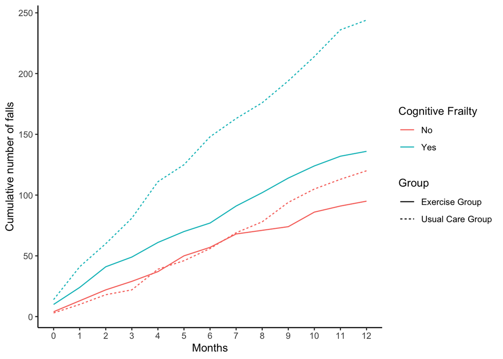

```r
Fallsmeans$Group[Fallsmeans$Group==0]<-"Usual Care Group"
Fallsmeans$Group[Fallsmeans$Group==1]<-"Exercise Group"


Cumulativefalls.Graph<- Fallsmeans %>%
  ggplot() + geom_line(aes(x=time, y=MonthCumulative, color=CogFrail, linetype=Group)) +
  labs(x="Months", y="Cumulative number of falls") + labs(color="Cognitive Frailty") +
  scale_x_continuous(breaks=seq(0,13,by=1)) + scale_y_continuous(breaks=seq(0,300,by=50))+
  theme_bw() + theme(panel.border = element_blank(), panel.grid.major = element_blank(),
                     panel.grid.minor = element_blank(), axis.line = element_line(colour = "black"))
Cumulativefalls.Graph
```

# 9) Figure 3- Differences in monthly compliance to the intervention based on cognitive frailty status and biological sex

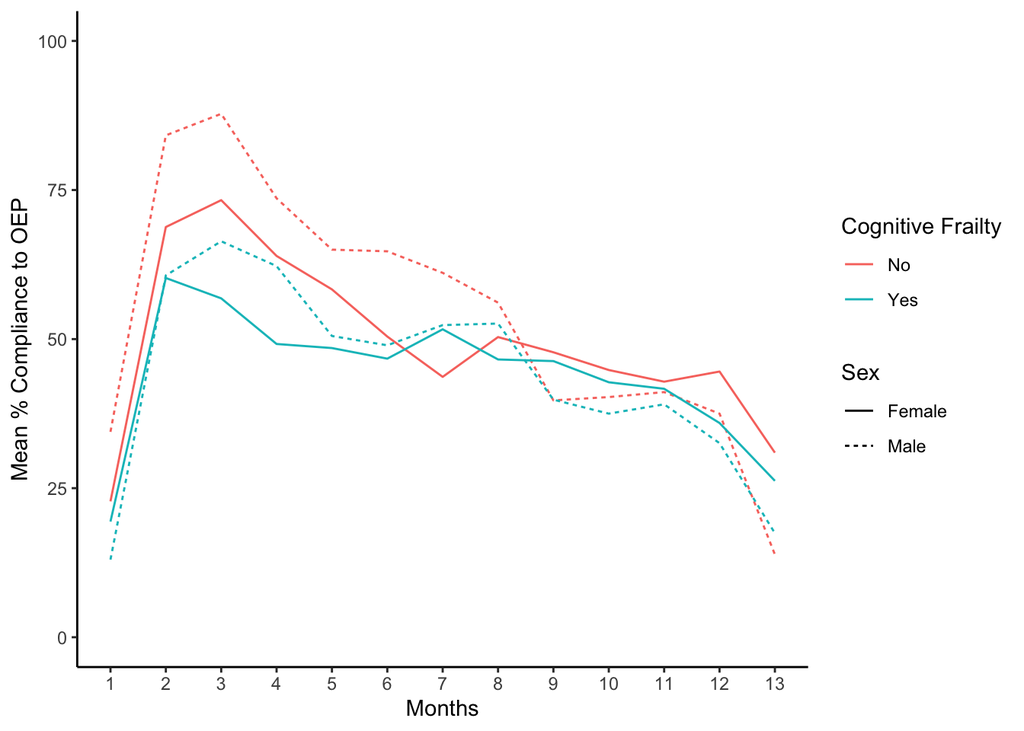

```r
comply.2<-lmer(OEPCOMP~factor(time)*CogFrail*Sex + 1 + (1|ID), compliancelong)
emms.2<-as.data.frame(lsmeans(comply.2, ~CogFrail|factor(time)|Sex))

Compliance.Graph.3<- emms.2 %>%
  ggplot() + geom_line(aes(x=time, y=lsmean, color=CogFrail, linetype=Sex)) +
  labs(x="Months", y="Mean % Compliance to OEP") + ylim(0,100) + scale_x_continuous(breaks=seq(0,13,by=1)) +
  labs(color="Cognitive Frailty") +
  theme_bw() + theme(panel.border = element_blank(), panel.grid.major = element_blank(),
                     panel.grid.minor = element_blank(), axis.line = element_line(colour = "black"))
Compliance.Graph.3
```

Estimated differences in average compliance for cognitively frail and non-cognitively frail participants

```r
comply<-lmer(OEPCOMP~factor(time)*CogFrail + 1 + (1|ID), compliancelong)
lsmeans(comply,~CogFrail)
```

```
## NOTE: Results may be misleading due to involvement in interactions
```

```
##  CogFrail   lsmean       SE  df lower.CL upper.CL
##  No       51.08866 3.498434 170 44.18270 57.99463
##  Yes      44.03088 3.224376 170 37.66591 50.39585
##
## Results are averaged over the levels of: time
## Degrees-of-freedom method: kenward-roger
## Confidence level used: 0.95
```

```r
contrast(lsmeans(comply, ~CogFrail), "pairwise", adj="none") #No significant difference overall
```

```
## NOTE: Results may be misleading due to involvement in interactions
```

```
##  contrast estimate       SE  df t.ratio p.value
##  No - Yes 7.057782 4.757693 170   1.483  0.1398
##
## Results are averaged over the levels of: time
## Degrees-of-freedom method: kenward-roger
```

Estimated differences in average compliance based on cognitive frailty and biological sex

```r
lsmeans(comply.2,~CogFrail|Sex)
```

```
## NOTE: Results may be misleading due to involvement in interactions
```

```
## Sex = Female:
##  CogFrail   lsmean       SE  df lower.CL upper.CL
##  No       49.42766 4.463627 168 40.61563 58.23968
##  Yes      43.99958 4.000562 168 36.10173 51.89743
##
## Sex = Male:
##  CogFrail   lsmean       SE  df lower.CL upper.CL
##  No       53.80164 5.704602 168 42.53970 65.06358
##  Yes      44.09054 5.523457 168 33.18622 54.99487
##
## Results are averaged over the levels of: time
## Degrees-of-freedom method: kenward-roger
## Confidence level used: 0.95
```

```r
contrast(lsmeans(comply.2, ~CogFrail|Sex), "pairwise", adj="none") #No significant difference overall
```

```
## NOTE: Results may be misleading due to involvement in interactions
```

```
## Sex = Female:
##  contrast estimate       SE  df t.ratio p.value
##  No - Yes 5.428076 5.994036 168   0.906  0.3665
##
## Sex = Male:
##  contrast estimate       SE  df t.ratio p.value
##  No - Yes 9.711093 7.940470 168   1.223  0.2230
##
## Results are averaged over the levels of: time
## Degrees-of-freedom method: kenward-roger
```

# 10) Table 4 - Primary and secondary outcomes at 12 months in exercise group based on cognitive frailty status and compliance to the intervention

Subset Exercise Group participants by cognitive frailty status

```r
CogFrail_OEP<-subset(OEP2, CogFrail=="Yes")
NoCogFrail_OEP<-subset(OEP2, CogFrail=="No")
```

Falls Incident Rate Ratio (Cognitively Frail Participants)

```r
mdl.nb<-glm.nb(TotalFalls~Compliant+scale(Gender,scale=FALSE)+offset(log(TotalExposure/365)),subset(CogFrail_OEP,exclude==0))
print(summary(mdl.nb))
```

```
##
## Call:
## glm.nb(formula = TotalFalls ~ Compliant + scale(Gender, scale = FALSE) +
##     offset(log(TotalExposure/365)), data = subset(CogFrail_OEP,
##     exclude == 0), init.theta = 1.180677101, link = log)
##
## Deviance Residuals:
##     Min       1Q   Median       3Q      Max
## -1.6031  -1.3316  -0.2480   0.3115   2.6463
##
## Coefficients:
##                              Estimate Std. Error z value Pr(>|z|)
## (Intercept)                   0.51089    0.19820   2.578  0.00995 **
## CompliantYes                 -0.05775    0.26380  -0.219  0.82671
## scale(Gender, scale = FALSE)  0.50746    0.26745   1.897  0.05778 .
## ---
## Signif. codes:  0 '***' 0.001 '**' 0.01 '*' 0.05 '.' 0.1 ' ' 1
##
## (Dispersion parameter for Negative Binomial(1.1807) family taken to be 1)
##
##     Null deviance: 97.972  on 92  degrees of freedom
## Residual deviance: 94.151  on 90  degrees of freedom
## AIC: 308.12
##
## Number of Fisher Scoring iterations: 1
##
##
##               Theta:  1.181
##           Std. Err.:  0.358
##
##  2 x log-likelihood:  -300.123
```

```r
SE<-sqrt(diag(vcovHC(mdl.nb,"HC1")))
p=2*pnorm(-abs(coef(mdl.nb)/SE))
print(cbind(coef(mdl.nb),SE,p))
```

```
##                                                 SE          p
## (Intercept)                   0.51088657 0.2136335 0.01678352
## CompliantYes                 -0.05775117 0.2876300 0.84086837
## scale(Gender, scale = FALSE)  0.50746132 0.2951436 0.08554691
```

```r
est<-cbind(Estimate=coef(mdl.nb),LL=coef(mdl.nb)-1.96*SE,UL=coef(mdl.nb)+1.96*SE)
exp_group<-exp(est)
print("Use these estimates and LL and UL for the 95% CI");exp_group
```

```
## [1] "Use these estimates and LL and UL for the 95% CI"
```

```
##                               Estimate        LL       UL
## (Intercept)                  1.6667682 1.0965457 2.533516
## CompliantYes                 0.9438848 0.5371349 1.658649
## scale(Gender, scale = FALSE) 1.6610689 0.9314430 2.962231
```

```r
print("No significant effect of compliance for CogFrail participants")
```

```
## [1] "No significant effect of compliance for CogFrail participants"
```

Falls Incident Rate Ratio (Non-Cognitively Frail Participants)

```r
mdl.nb<-glm.nb(TotalFalls~Compliant+scale(Gender,scale=FALSE)+offset(log(TotalExposure/365)),subset(NoCogFrail_OEP,exclude==0))
print(summary(mdl.nb))
```

```
##
## Call:
## glm.nb(formula = TotalFalls ~ Compliant + scale(Gender, scale = FALSE) +
##     offset(log(TotalExposure/365)), data = subset(NoCogFrail_OEP,
##     exclude == 0), init.theta = 2.871932128, link = log)
##
## Deviance Residuals:
##     Min       1Q   Median       3Q      Max
## -1.6832  -1.2807  -0.2784   0.4386   2.4821
##
## Coefficients:
##                              Estimate Std. Error z value Pr(>|z|)
## (Intercept)                    0.1386     0.1990   0.696   0.4862
## CompliantYes                   0.1385     0.2535   0.546   0.5848
## scale(Gender, scale = FALSE)   0.5022     0.2486   2.020   0.0434 *
## ---
## Signif. codes:  0 '***' 0.001 '**' 0.01 '*' 0.05 '.' 0.1 ' ' 1
##
## (Dispersion parameter for Negative Binomial(2.8719) family taken to be 1)
##
##     Null deviance: 84.383  on 78  degrees of freedom
## Residual deviance: 80.154  on 76  degrees of freedom
## AIC: 233.89
##
## Number of Fisher Scoring iterations: 1
##
##
##               Theta:  2.87
##           Std. Err.:  1.56
##
##  2 x log-likelihood:  -225.892
```

```r
SE<-sqrt(diag(vcovHC(mdl.nb,"HC1")))
p=2*pnorm(-abs(coef(mdl.nb)/SE))
print(cbind(coef(mdl.nb),SE,p))
```

```
##                                               SE          p
## (Intercept)                  0.1386057 0.1898582 0.46536071
## CompliantYes                 0.1385455 0.2600826 0.59424248
## scale(Gender, scale = FALSE) 0.5021758 0.2629538 0.05616555
```

```r
est<-cbind(Estimate=coef(mdl.nb),LL=coef(mdl.nb)-1.96*SE,UL=coef(mdl.nb)+1.96*SE)
exp_group<-exp(est)
print("Use these estimates and LL and UL for the 95% CI");exp_group
```

```
## [1] "Use these estimates and LL and UL for the 95% CI"
```

```
##                              Estimate        LL       UL
## (Intercept)                  1.148671 0.7917445 1.666504
## CompliantYes                 1.148602 0.6898947 1.912301
## scale(Gender, scale = FALSE) 1.652312 0.9868732 2.766451
```

```r
print("No significant effect of compliance for Non-CogFrail participants")
```

```
## [1] "No significant effect of compliance for Non-CogFrail participants"
```

Falls Per Person-Year (Cognitively Frail Participants)

```r
CogFrail_OEP$falls_ppy<-CogFrail_OEP$TotalFalls/(CogFrail_OEP$TotalExposure/365)
NoCogFrail_OEP$falls_ppy<-NoCogFrail_OEP$TotalFalls/(NoCogFrail_OEP$TotalExposure/365)


fallsppy_comply<-lm(falls_ppy~Compliant, CogFrail_OEP)
summary(fallsppy_comply)
```

```
##
## Call:
## lm(formula = falls_ppy ~ Compliant, data = CogFrail_OEP)
##
## Residuals:
##     Min      1Q  Median      3Q     Max
## -1.5970 -1.5918 -0.5918  0.4082 11.4030
##
## Coefficients:
##               Estimate Std. Error t value Pr(>|t|)
## (Intercept)   1.597031   0.339473   4.704 9.04e-06 ***
## CompliantYes -0.005194   0.467679  -0.011    0.991
## ---
## Signif. codes:  0 '***' 0.001 '**' 0.01 '*' 0.05 '.' 0.1 ' ' 1
##
## Residual standard error: 2.252 on 91 degrees of freedom
## Multiple R-squared:  1.355e-06,  Adjusted R-squared:  -0.01099
## F-statistic: 0.0001233 on 1 and 91 DF,  p-value: 0.9912
```

```r
lsmeans(fallsppy_comply, ~Compliant)
```

```
##  Compliant   lsmean        SE df  lower.CL upper.CL
##  No        1.597031 0.3394726 91 0.9227104 2.271351
##  Yes       1.591837 0.3216866 91 0.9528458 2.230828
##
## Confidence level used: 0.95
```

```r
contrast(lsmeans(fallsppy_comply, ~~Compliant), "trt.vs.ctrl", adj="none")
```

```
##  contrast    estimate        SE df t.ratio p.value
##  Yes - No -0.00519416 0.4676792 91  -0.011  0.9912
```

Falls Per Person-Year (Non-Cognitively Frail Participants)

```r
fallsppy_comply<-lm(falls_ppy~Compliant, NoCogFrail_OEP)
summary(fallsppy_comply)
```

```
##
## Call:
## lm(formula = falls_ppy ~ Compliant, data = NoCogFrail_OEP)
##
## Residuals:
##     Min      1Q  Median      3Q     Max
## -1.3488 -1.1457 -0.3488  0.6512  6.6512
##
## Coefficients:
##              Estimate Std. Error t value Pr(>|t|)
## (Intercept)    1.1457     0.2518   4.550 1.97e-05 ***
## CompliantYes   0.2031     0.3413   0.595    0.553
## ---
## Signif. codes:  0 '***' 0.001 '**' 0.01 '*' 0.05 '.' 0.1 ' ' 1
##
## Residual standard error: 1.511 on 77 degrees of freedom
## Multiple R-squared:  0.00458,    Adjusted R-squared:  -0.008347
## F-statistic: 0.3543 on 1 and 77 DF,  p-value: 0.5534
```

```r
lsmeans(fallsppy_comply, ~Compliant)
```

```
##  Compliant   lsmean        SE df  lower.CL upper.CL
##  No        1.145689 0.2517956 77 0.6442999 1.647078
##  Yes       1.348837 0.2303908 77 0.8900706 1.807604
##
## Confidence level used: 0.95
```

```r
contrast(lsmeans(fallsppy_comply, ~~Compliant), "trt.vs.ctrl", adj="none")
```

```
##  contrast  estimate       SE df t.ratio p.value
##  Yes - No 0.2031483 0.341293 77   0.595  0.5534
```

PPA

```r
PPA_lm<-lmer(PPA~Compliant*CogFrail*factor(time) + scale(Gender,scale=FALSE) + PPAbaseline + 1 + (1|ID), subset(OEP3, exclude == 0))
anova(PPA_lm)
```

```
## Type III Analysis of Variance Table with Satterthwaite's method
##                                  Sum Sq Mean Sq NumDF  DenDF F value    Pr(>F)
## Compliant                        0.4179  0.4179     1 137.62  0.8871 0.3479018
## CogFrail                         0.0183  0.0183     1 137.16  0.0389 0.8439656
## factor(time)                     0.9435  0.9435     1 132.59  2.0028 0.1593522
## scale(Gender, scale = FALSE)     0.0350  0.0350     1 136.44  0.0743 0.7856240
## PPAbaseline                     24.9606 24.9606     1 136.05 52.9828 2.433e-11
## Compliant:CogFrail               0.2110  0.2110     1 137.62  0.4479 0.5044429
## Compliant:factor(time)           0.0351  0.0351     1 132.59  0.0745 0.7853589
## CogFrail:factor(time)            5.3374  5.3374     1 132.58 11.3295 0.0009983
## Compliant:CogFrail:factor(time)  0.0027  0.0027     1 132.59  0.0058 0.9392909
##
## Compliant
## CogFrail
## factor(time)
## scale(Gender, scale = FALSE)
## PPAbaseline                     ***
## Compliant:CogFrail
## Compliant:factor(time)
## CogFrail:factor(time)           ***
## Compliant:CogFrail:factor(time)
## ---
## Signif. codes:  0 '***' 0.001 '**' 0.01 '*' 0.05 '.' 0.1 ' ' 1
```

```r
lsmeans(PPA_lm, ~Compliant|CogFrail|factor(time))
```

```
## CogFrail = No, time = 2:
##  Compliant   lsmean        SE     df lower.CL upper.CL
##  No        1.677958 0.1995168 215.52 1.284704 2.071212
##  Yes       1.749516 0.1455960 208.38 1.462486 2.036546
##
## CogFrail = Yes, time = 2:
##  Compliant   lsmean        SE     df lower.CL upper.CL
##  No        1.924198 0.1910927 215.69 1.547550 2.300846
##  Yes       2.176687 0.1388456 213.08 1.903000 2.450373
##
## CogFrail = No, time = 3:
##  Compliant   lsmean        SE     df lower.CL upper.CL
##  No        2.146107 0.2073623 225.60 1.737492 2.554721
##  Yes       2.153938 0.1470181 211.35 1.864128 2.443747
##
## CogFrail = Yes, time = 3:
##  Compliant   lsmean        SE     df lower.CL upper.CL
##  No        1.764120 0.1980266 225.08 1.373897 2.154344
##  Yes       1.980733 0.1413419 218.13 1.702162 2.259303
##
## Results are averaged over the levels of: Gender
## Degrees-of-freedom method: kenward-roger
## Confidence level used: 0.95
```

```r
contrast(lsmeans(PPA_lm, ~Compliant|CogFrail|factor(time)), "trt.vs.ctrl", adj="none")
```

```
## CogFrail = No, time = 2:
##  contrast   estimate        SE     df t.ratio p.value
##  Yes - No 0.07155806 0.2448274 214.98   0.292  0.7704
##
## CogFrail = Yes, time = 2:
##  contrast   estimate        SE     df t.ratio p.value
##  Yes - No 0.25248856 0.2341314 216.29   1.078  0.2821
##
## CogFrail = No, time = 3:
##  contrast   estimate        SE     df t.ratio p.value
##  Yes - No 0.00783079 0.2520161 222.80   0.031  0.9752
##
## CogFrail = Yes, time = 3:
##  contrast   estimate        SE     df t.ratio p.value
##  Yes - No 0.21661231 0.2409391 223.90   0.899  0.3696
##
## Results are averaged over the levels of: Gender
## Degrees-of-freedom method: kenward-roger
```

```r
confint(contrast(lsmeans(PPA_lm, ~Compliant|CogFrail|factor(time)), "trt.vs.ctrl", adj="none"))
```

```
## CogFrail = No, time = 2:
##  contrast   estimate        SE     df   lower.CL  upper.CL
##  Yes - No 0.07155806 0.2448274 214.98 -0.4110114 0.5541276
##
## CogFrail = Yes, time = 2:
##  contrast   estimate        SE     df   lower.CL  upper.CL
##  Yes - No 0.25248856 0.2341314 216.29 -0.2089827 0.7139598
##
## CogFrail = No, time = 3:
##  contrast   estimate        SE     df   lower.CL  upper.CL
##  Yes - No 0.00783079 0.2520161 222.80 -0.4888094 0.5044710
##
## CogFrail = Yes, time = 3:
##  contrast   estimate        SE     df   lower.CL  upper.CL
##  Yes - No 0.21661231 0.2409391 223.90 -0.2581860 0.6914106
##
## Results are averaged over the levels of: Gender
## Degrees-of-freedom method: kenward-roger
## Confidence level used: 0.95
```

```r
print("No significant effects")
```

```
## [1] "No significant effects"
```

SPPB

```r
GS_lm<-lmer(SPPB~Compliant*CogFrail*factor(time) + scale(Gender,scale=FALSE) + SPPBbaseline + 1 + (1|ID), subset(OEP3, exclude == 0))
anova(GS_lm)
```

```
## Type III Analysis of Variance Table with Satterthwaite's method
##                                 Sum Sq Mean Sq NumDF  DenDF F value    Pr(>F)
## Compliant                        6.472   6.472     1 136.09  6.6540   0.01095
## CogFrail                         1.195   1.195     1 136.06  1.2289   0.26958
## factor(time)                     1.419   1.419     1 127.59  1.4585   0.22940
## scale(Gender, scale = FALSE)     0.794   0.794     1 135.35  0.8162   0.36789
## SPPBbaseline                    80.102  80.102     1 136.09 82.3573 1.139e-15
## Compliant:CogFrail               0.036   0.036     1 136.00  0.0371   0.84763
## Compliant:factor(time)           3.307   3.307     1 127.58  3.3996   0.06753
## CogFrail:factor(time)            3.784   3.784     1 127.66  3.8905   0.05072
## Compliant:CogFrail:factor(time)  3.005   3.005     1 127.63  3.0892   0.08121
##
## Compliant                       *
## CogFrail
## factor(time)
## scale(Gender, scale = FALSE)
## SPPBbaseline                    ***
## Compliant:CogFrail
## Compliant:factor(time)          .
## CogFrail:factor(time)           .
## Compliant:CogFrail:factor(time) .
## ---
## Signif. codes:  0 '***' 0.001 '**' 0.01 '*' 0.05 '.' 0.1 ' ' 1
```

```r
lsmeans(GS_lm, ~Compliant|CogFrail|factor(time))
```

```
## CogFrail = No, time = 2:
##  Compliant   lsmean        SE     df lower.CL upper.CL
##  No        7.686118 0.3573432 195.22 6.981370 8.390867
##  Yes       8.304141 0.2600147 179.58 7.791064 8.817218
##
## CogFrail = Yes, time = 2:
##  Compliant   lsmean        SE     df lower.CL upper.CL
##  No        7.788240 0.3416021 183.94 7.114278 8.462203
##  Yes       8.039804 0.2459103 185.09 7.554657 8.524952
##
## CogFrail = No, time = 3:
##  Compliant   lsmean        SE     df lower.CL upper.CL
##  No        7.776359 0.3599153 197.96 7.066598 8.486119
##  Yes       8.417412 0.2621021 182.99 7.900282 8.934543
##
## CogFrail = Yes, time = 3:
##  Compliant   lsmean        SE     df lower.CL upper.CL
##  No        6.885443 0.3508938 194.76 6.193403 7.577482
##  Yes       8.095933 0.2510022 193.48 7.600881 8.590985
##
## Results are averaged over the levels of: Gender
## Degrees-of-freedom method: kenward-roger
## Confidence level used: 0.95
```

```r
contrast(lsmeans(GS_lm, ~Compliant|CogFrail|factor(time)), "trt.vs.ctrl", adj="none")
```

```
## CogFrail = No, time = 2:
##  contrast  estimate        SE     df t.ratio p.value
##  Yes - No 0.6180225 0.4250614 193.25   1.454  0.1476
##
## CogFrail = Yes, time = 2:
##  contrast  estimate        SE     df t.ratio p.value
##  Yes - No 0.2515636 0.4023332 189.85   0.625  0.5326
##
## CogFrail = No, time = 3:
##  contrast  estimate        SE     df t.ratio p.value
##  Yes - No 0.6410538 0.4303815 198.07   1.490  0.1379
##
## CogFrail = Yes, time = 3:
##  contrast  estimate        SE     df t.ratio p.value
##  Yes - No 1.2104904 0.4129084 200.07   2.932  0.0038
##
## Results are averaged over the levels of: Gender
## Degrees-of-freedom method: kenward-roger
```

```r
confint(contrast(lsmeans(GS_lm, ~Compliant|CogFrail|factor(time)), "trt.vs.ctrl", adj="none"))
```

```
## CogFrail = No, time = 2:
##  contrast  estimate        SE     df   lower.CL upper.CL
##  Yes - No 0.6180225 0.4250614 193.25 -0.2203327 1.456378
##
## CogFrail = Yes, time = 2:
##  contrast  estimate        SE     df   lower.CL upper.CL
##  Yes - No 0.2515636 0.4023332 189.85 -0.5420538 1.045181
##
## CogFrail = No, time = 3:
##  contrast  estimate        SE     df   lower.CL upper.CL
##  Yes - No 0.6410538 0.4303815 198.07 -0.2076642 1.489772
##
## CogFrail = Yes, time = 3:
##  contrast  estimate        SE     df   lower.CL upper.CL
##  Yes - No 1.2104904 0.4129084 200.07  0.3962796 2.024701
##
## Results are averaged over the levels of: Gender
## Degrees-of-freedom method: kenward-roger
## Confidence level used: 0.95
```

```r
print("Significant difference based on compliance for CogFrail participants at post-intervention")
```

```
## [1] "Significant difference based on compliance for CogFrail participants at post-intervention"
```

Gait Speed

```r
GS_lm<-lmer(GaitSpeed~Compliant*CogFrail*factor(time) + scale(Gender,scale=FALSE) + GaitSpeedbaseline + 1 + (1|ID), subset(OEP3, exclude == 0))
anova(GS_lm)
```

```
## Type III Analysis of Variance Table with Satterthwaite's method
##                                  Sum Sq Mean Sq NumDF  DenDF  F value  Pr(>F)
## Compliant                       0.00381 0.00381     1 134.32   0.4678 0.49517
## CogFrail                        0.00627 0.00627     1 134.58   0.7699 0.38180
## factor(time)                    0.02549 0.02549     1 126.26   3.1285 0.07935
## scale(Gender, scale = FALSE)    0.01156 0.01156     1 133.44   1.4190 0.23568
## GaitSpeedbaseline               1.53999 1.53999     1 132.91 189.0416 < 2e-16
## Compliant:CogFrail              0.00019 0.00019     1 134.35   0.0238 0.87759
## Compliant:factor(time)          0.02343 0.02343     1 126.18   2.8766 0.09234
## CogFrail:factor(time)           0.00763 0.00763     1 126.27   0.9370 0.33490
## Compliant:CogFrail:factor(time) 0.00504 0.00504     1 126.26   0.6193 0.43279
##
## Compliant
## CogFrail
## factor(time)                    .
## scale(Gender, scale = FALSE)
## GaitSpeedbaseline               ***
## Compliant:CogFrail
## Compliant:factor(time)          .
## CogFrail:factor(time)
## Compliant:CogFrail:factor(time)
## ---
## Signif. codes:  0 '***' 0.001 '**' 0.01 '*' 0.05 '.' 0.1 ' ' 1
```

```r
lsmeans(GS_lm, ~Compliant|CogFrail|factor(time))
```

```
## CogFrail = No, time = 2:
##  Compliant    lsmean         SE     df  lower.CL  upper.CL
##  No        0.8270895 0.03109046 199.63 0.7657816 0.8883973
##  Yes       0.8354961 0.02310563 182.53 0.7899076 0.8810845
##
## CogFrail = Yes, time = 2:
##  Compliant    lsmean         SE     df  lower.CL  upper.CL
##  No        0.8748203 0.02971499 190.71 0.8162081 0.9334326
##  Yes       0.8569279 0.02163460 190.31 0.8142535 0.8996023
##
## CogFrail = No, time = 3:
##  Compliant    lsmean         SE     df  lower.CL  upper.CL
##  No        0.8062790 0.03149476 204.34 0.7441827 0.8683754
##  Yes       0.8368193 0.02332327 186.41 0.7908078 0.8828308
##
## CogFrail = Yes, time = 3:
##  Compliant    lsmean         SE     df  lower.CL  upper.CL
##  No        0.8113054 0.03057868 201.63 0.7510104 0.8716004
##  Yes       0.8538461 0.02206546 198.00 0.8103326 0.8973595
##
## Results are averaged over the levels of: Gender
## Degrees-of-freedom method: kenward-roger
## Confidence level used: 0.95
```

```r
contrast(lsmeans(GS_lm, ~Compliant|CogFrail|factor(time)), "trt.vs.ctrl", adj="none")
```

```
## CogFrail = No, time = 2:
##  contrast    estimate         SE     df t.ratio p.value
##  Yes - No  0.00840660 0.03773913 196.40   0.223  0.8240
##
## CogFrail = Yes, time = 2:
##  contrast    estimate         SE     df t.ratio p.value
##  Yes - No -0.01789244 0.03558409 194.28  -0.503  0.6157
##
## CogFrail = No, time = 3:
##  contrast    estimate         SE     df t.ratio p.value
##  Yes - No  0.03054025 0.03830894 202.00   0.797  0.4263
##
## CogFrail = Yes, time = 3:
##  contrast    estimate         SE     df t.ratio p.value
##  Yes - No  0.04254071 0.03656471 204.44   1.163  0.2460
##
## Results are averaged over the levels of: Gender
## Degrees-of-freedom method: kenward-roger
```

```r
confint(contrast(lsmeans(GS_lm, ~Compliant|CogFrail|factor(time)), "trt.vs.ctrl", adj="none"))
```

```
## CogFrail = No, time = 2:
##  contrast    estimate         SE     df    lower.CL   upper.CL
##  Yes - No  0.00840660 0.03773913 196.40 -0.06601935 0.08283256
##
## CogFrail = Yes, time = 2:
##  contrast    estimate         SE     df    lower.CL   upper.CL
##  Yes - No -0.01789244 0.03558409 194.28 -0.08807314 0.05228826
##
## CogFrail = No, time = 3:
##  contrast    estimate         SE     df    lower.CL   upper.CL
##  Yes - No  0.03054025 0.03830894 202.00 -0.04499643 0.10607694
##
## CogFrail = Yes, time = 3:
##  contrast    estimate         SE     df    lower.CL   upper.CL
##  Yes - No  0.04254071 0.03656471 204.44 -0.02955157 0.11463298
##
## Results are averaged over the levels of: Gender
## Degrees-of-freedom method: kenward-roger
## Confidence level used: 0.95
```

```r
print("No significant effects")
```

```
## [1] "No significant effects"
```

MoCA

```r
MoCA_lm<-lmer(MoCA~Compliant*CogFrail*factor(time) + scale(Gender,scale=FALSE) + MoCAbaseline + 1 + (1|ID), subset(OEP3, exclude==0))
anova(MoCA_lm)
```

```
## Type III Analysis of Variance Table with Satterthwaite's method
##                                  Sum Sq Mean Sq NumDF  DenDF F value    Pr(>F)
## Compliant                         1.606   1.606     1 133.90  0.1483   0.70081
## CogFrail                         15.641  15.641     1 131.29  1.4439   0.23167
## factor(time)                      6.479   6.479     1 134.59  0.5981   0.44067
## scale(Gender, scale = FALSE)      6.211   6.211     1 131.62  0.5734   0.45026
## MoCAbaseline                    249.493 249.493     1 136.53 23.0318 4.124e-06
## Compliant:CogFrail                0.556   0.556     1 133.28  0.0513   0.82114
## Compliant:factor(time)            3.229   3.229     1 134.59  0.2981   0.58597
## CogFrail:factor(time)            31.666  31.666     1 134.60  2.9232   0.08962
## Compliant:CogFrail:factor(time)  18.870  18.870     1 134.60  1.7420   0.18913
##
## Compliant
## CogFrail
## factor(time)
## scale(Gender, scale = FALSE)
## MoCAbaseline                    ***
## Compliant:CogFrail
## Compliant:factor(time)
## CogFrail:factor(time)           .
## Compliant:CogFrail:factor(time)
## ---
## Signif. codes:  0 '***' 0.001 '**' 0.01 '*' 0.05 '.' 0.1 ' ' 1
```

```r
lsmeans(MoCA_lm, ~Compliant|CogFrail|factor(time))
```

```
## CogFrail = No, time = 2:
##  Compliant   lsmean        SE     df lower.CL upper.CL
##  No        23.22492 0.7208512 255.17 21.80534 24.64449
##  Yes       23.62992 0.5277610 253.56 22.59057 24.66927
##
## CogFrail = Yes, time = 2:
##  Compliant   lsmean        SE     df lower.CL upper.CL
##  No        23.83651 0.6897602 253.61 22.47812 25.19489
##  Yes       23.31038 0.5054555 254.55 22.31498 24.30579
##
## CogFrail = No, time = 3:
##  Compliant   lsmean        SE     df lower.CL upper.CL
##  No        23.95965 0.7576461 255.40 22.46763 25.45168
##  Yes       23.69969 0.5277610 253.56 22.66033 24.73904
##
## CogFrail = Yes, time = 3:
##  Compliant   lsmean        SE     df lower.CL upper.CL
##  No        21.96866 0.7374913 254.31 20.51629 23.42103
##  Yes       23.04537 0.5096437 254.63 22.04171 24.04902
##
## Results are averaged over the levels of: Gender
## Degrees-of-freedom method: kenward-roger
## Confidence level used: 0.95
```

```r
contrast(lsmeans(MoCA_lm, ~Compliant|CogFrail|factor(time)), "trt.vs.ctrl", adj="none")
```

```
## CogFrail = No, time = 2:
##  contrast   estimate        SE     df t.ratio p.value
##  Yes - No  0.4050049 0.8840789 255.40   0.458  0.6473
##
## CogFrail = Yes, time = 2:
##  contrast   estimate        SE     df t.ratio p.value
##  Yes - No -0.5261222 0.8391931 255.27  -0.627  0.5313
##
## CogFrail = No, time = 3:
##  contrast   estimate        SE     df t.ratio p.value
##  Yes - No -0.2599662 0.9124621 255.52  -0.285  0.7759
##
## CogFrail = Yes, time = 3:
##  contrast   estimate        SE     df t.ratio p.value
##  Yes - No  1.0767044 0.8822195 255.49   1.220  0.2234
##
## Results are averaged over the levels of: Gender
## Degrees-of-freedom method: kenward-roger
```

```r
confint(contrast(lsmeans(MoCA_lm, ~Compliant|CogFrail|factor(time)), "trt.vs.ctrl", adj="none"))
```

```
## CogFrail = No, time = 2:
##  contrast   estimate        SE     df   lower.CL upper.CL
##  Yes - No  0.4050049 0.8840789 255.40 -1.3360079 2.146018
##
## CogFrail = Yes, time = 2:
##  contrast   estimate        SE     df   lower.CL upper.CL
##  Yes - No -0.5261222 0.8391931 255.27 -2.1787458 1.126501
##
## CogFrail = No, time = 3:
##  contrast   estimate        SE     df   lower.CL upper.CL
##  Yes - No -0.2599662 0.9124621 255.52 -2.0568698 1.536938
##
## CogFrail = Yes, time = 3:
##  contrast   estimate        SE     df   lower.CL upper.CL
##  Yes - No  1.0767044 0.8822195 255.49 -0.6606438 2.814053
##
## Results are averaged over the levels of: Gender
## Degrees-of-freedom method: kenward-roger
## Confidence level used: 0.95
```

```r
print("No significant differences")
```

```
## [1] "No significant differences"
```